# MA681 Final Project

### Logistic regression

The analyses above were meant to get a sense of performance differences between groups while assuming that all experimental parameters were relevant, but I was also interested in estimating the importance of each factor in predicting choice. Such predictions can often be done with linear models. However, due to the non-Gaussian nature of the proportion of choices, as well as the predictors, I decided to run a logistic regression to predict the proportion of trials per subject, using group, handling time, and reward amount as predictors *(using a quasi-binomial GLM)*. I used Akaike Information Criterion (AIC) to identify which combinations of predictors significantly reduced the -2 log-likelihood while penalizing the addition of predictors. Figure 9 shows the results.

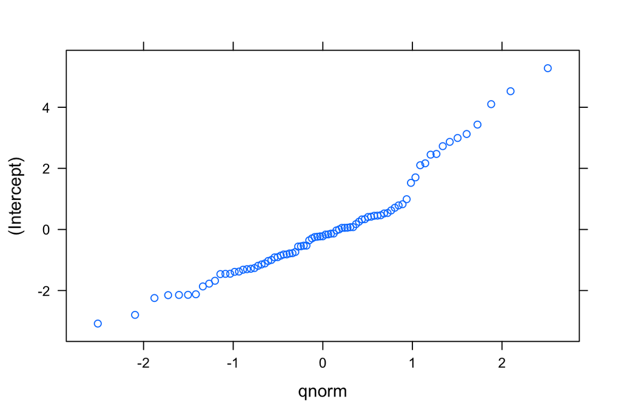

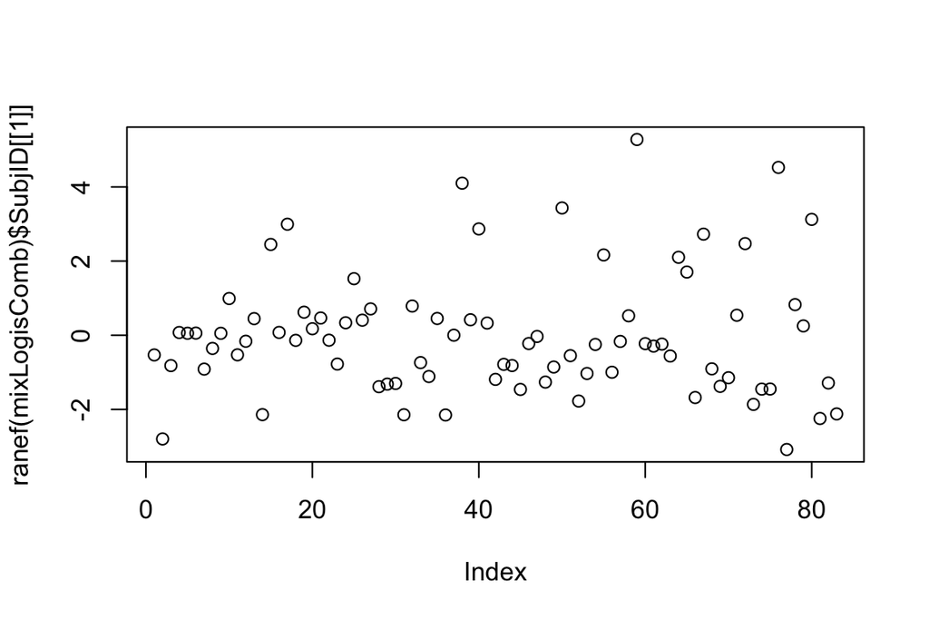

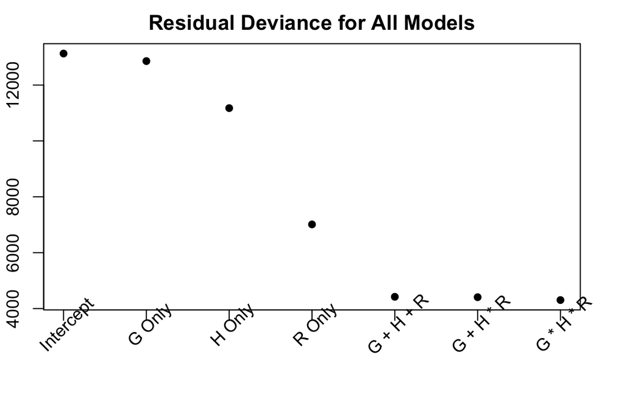

Fitting generalized (quasibinomial/logit) linear model: testBinom ~ factor(Group) + Handling + Reward

|  | Estimate | Std. Error | t value | Pr(> |
| --- | --- | --- | --- | --- |
| **(Intercept)** | -0.7 | 0.24 | -2.9 | 0.0036 |
| **factor(Group)Cognitive** | 1.5 | 0.21 | 7.1 | 4e-12 |
| **factor(Group)Physical** | 0.36 | 0.2 | 1.8 | 0.074 |
| **factor(Group)Easy** | 1.1 | 0.21 | 5.1 | 4.1e-07 |
| **Handling** | -0.27 | 0.017 | -16 | 7.9e-48 |
| **Reward** | 0.31 | 0.019 | 16 | 5.8e-52 |

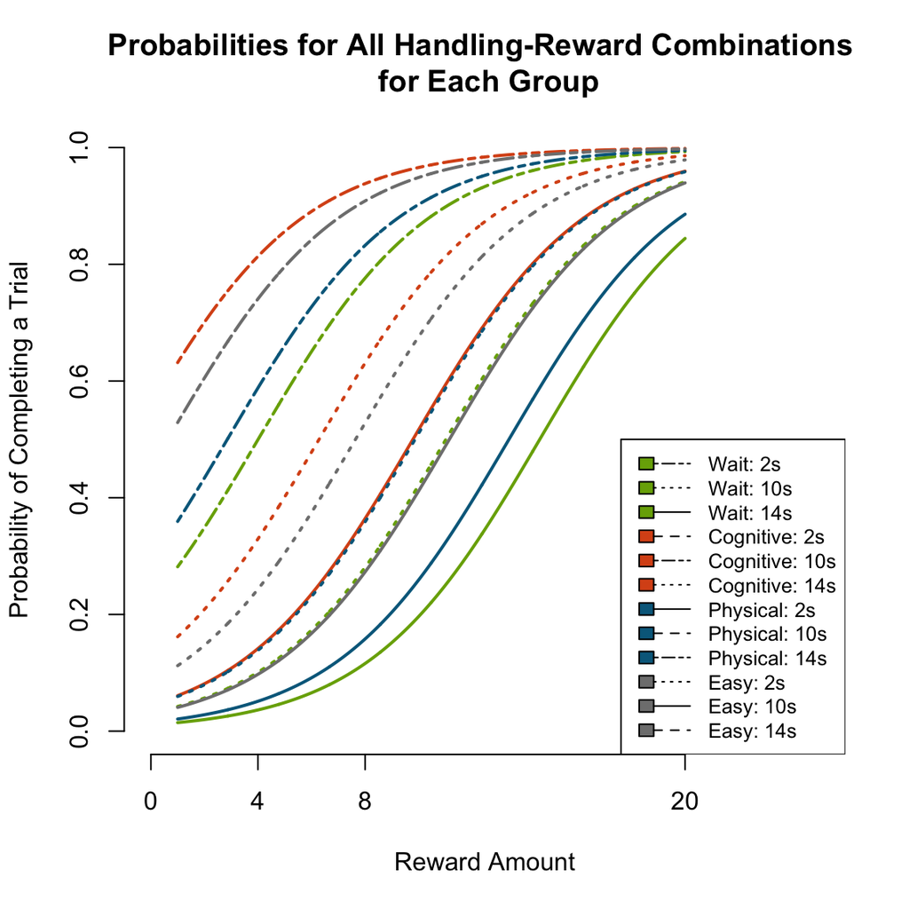